# REPORT of CARE STUDY

## Welcome to CARE Study!

One in three children suffers from allergies:

If someone in the family is affected, the risk of allergies for the newborn is over 50%. These include hay fever, asthma, food allergies and neurodermatitis (atopic eczema/atopic dermatitis).

CARE study

**In the first year of life**: Short weekly questionnaires on nutrition and health (online or on paper, in encrypted form),

sending in 5 stool samples and 4 visits with skin examination:

- At birth Visit to the hospital
- At the age of 3 weeks, home visit (by a nursing professional)
- At the age of 4 months, Visit to the children’s hospital
- At the age of 12 months, visit to the children’s hospital with allergy testing

**From the second year of life**: Questionnaire on nutrition and health (online or on paper, in encrypted form), sending in stool samples:

- At the age of 18 months
- At the age of 2 and 3 years including visit to the children’s hospital with skin examination and allergy testing

**Practical procedure of the study** :

Centers in *St Gallen, Switzerland* : Regular visit.

**SECUTRIAL** : Patient questionnaires, physical examination

**OPENSPECIMEN** : Collection of blood/ skin swabs/ if necessary skin biopsy

## CARE

### SECUTRIAL (2025-02-10)

> **389** ID in CARE secutrial

> **1505** visit in CARE secutrial

Total number of ID per visit in CARE

| key | value |
| --- | --- |
| Birth_visit_ID | 331 |
| MONTH4_visit_ID | 295 |
| YEAR1_visit_ID | 226 |
| YEAR1.5_visit_ID | 185 |
| YEAR2_visit_ID | 188 |
| YEAR3_visit_ID | 160 |
| YEAR5_visit_ID | 120 |

### OPENSPECIMEN (2025-02-10)

> **365** ID in CARE openspecimen

> **17660** samples in CARE openspecimen

Total number of samples in CARE openspecimen

| Specimen_Type | Total |
| --- | --- |
| Feces | 11202 |
| Swabs | 3225 |
| skin_swab | 2554 |
| whole_blood | 107 |
| edta_aliquot | 221 |
| serum_aliquot | 351 |

## CARE SECUTRIAL

> **389** Patient ID

> **58** birth ID missing

> **2024** col without any value

### CARE DETAILS

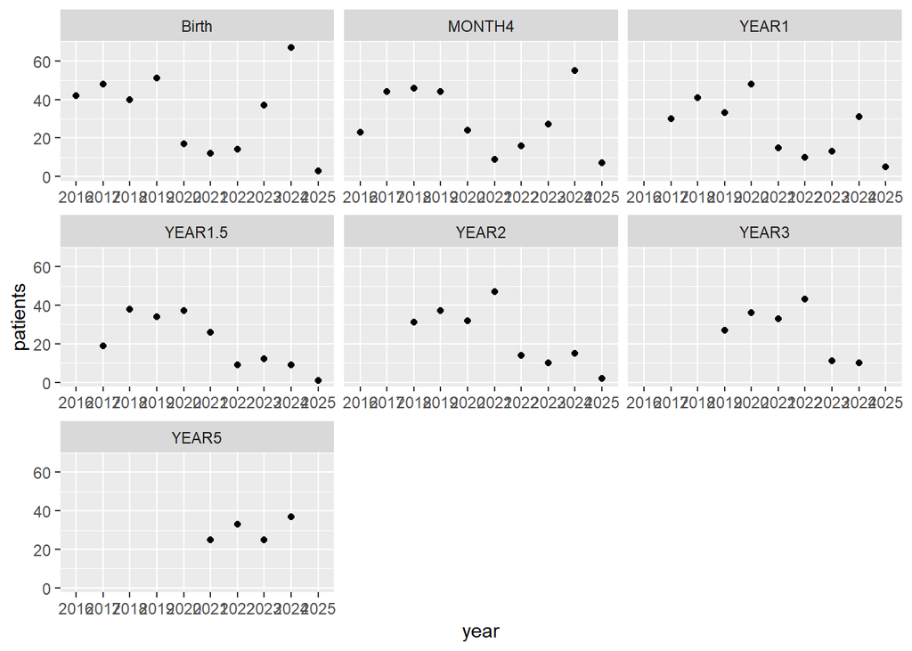

#### AD

> First look at the AD diagnosis

> Classified as leicht, mittel and schwer

> There is **110** inclusion with at least 1 AD event out of the **389** inclusions

> The reste of inclusions ( **279**) are classified as non-AD

| Visit | AD | nb_patient |
| --- | --- | --- |
| MONTH4_fwdiagnose_AD_1 | leicht (<25 punkte) | 43 |
| MONTH4_fwdiagnose_AD_1 | mittel (>25 und <60 punkten) | 12 |
| MONTH4_fwdiagnose_AD_1 | NA | 334 |
| YEAR1_fw12month_diagnose_AD_2 | leicht (<25 punkte) | 37 |
| YEAR1_fw12month_diagnose_AD_2 | mittel (>25 und <60 punkten) | 3 |
| YEAR1_fw12month_diagnose_AD_2 | NA | 349 |
| YEAR2_fw2y_diagnose_AD_4 | leicht (<25 punkte) | 33 |
| YEAR2_fw2y_diagnose_AD_4 | mittel (>25 und <60 punkten) | 4 |
| YEAR2_fw2y_diagnose_AD_4 | schwer (>60 punkte) | 1 |
| YEAR2_fw2y_diagnose_AD_4 | NA | 351 |
| YEAR3_fw36month_diagnose_AD_5 | leicht (<25 punkte) | 32 |
| YEAR3_fw36month_diagnose_AD_5 | mittel (>25 und <60 punkten) | 2 |
| YEAR3_fw36month_diagnose_AD_5 | NA | 355 |

> First look at the evolution of the AD classification

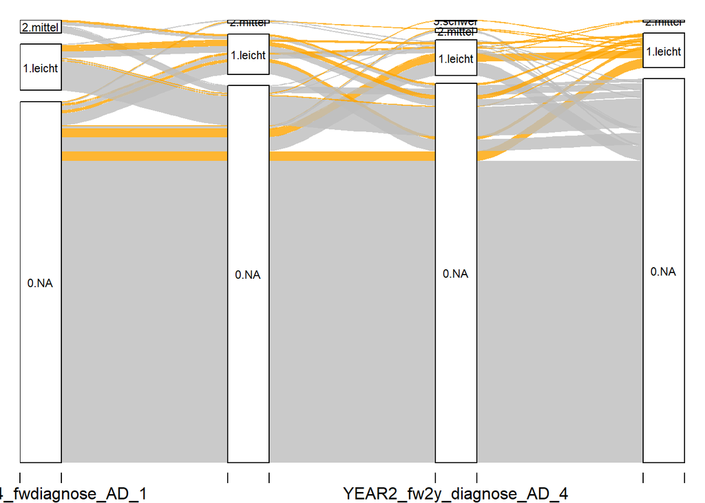

## CARE OPENSPECIMEN

| Specimen_Type | Total |
| --- | --- |
| Feces | 11202 |
| Swabs | 3225 |
| skin_swab | 2554 |
| whole_blood | 107 |
| edta_aliquot | 221 |
| serum_aliquot | 351 |

# data exploration

> Information available:
> - Familly history (like allergies, asthma, psoriasis)
> - Children diseases (like allergies, asthma, psoriasis)
> - Treatments (like Cortison, Antihistamine )

> Plot of the scorad score A

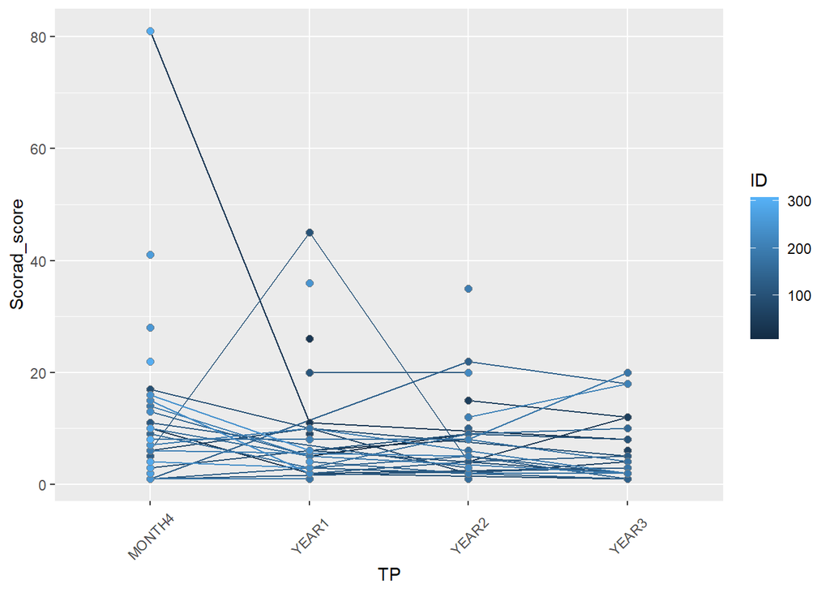